# FFT_SSVEP_analysis

#### analysis II

**modulation** ~ **condition**

ANOVA_RM: modulation ~ CONDITION ( attended + irrelevant attended + not attended irrelevant + attended irrelevant + not attended not attended + attended not attended + irrelevant )

- post-hoc t-test contrasting differences between defined levels
- post-hoc t-test difference of post-cue modulation for attended vs unattended color

```r
dat2plot <- DataIn %>%
  filter(RDK_position2=="peri") %>%
  filter(RDK_ispresented=="presented")%>%
  group_by(subjects, time, RDK_isattended2, RDK_colorlum)%>%
  summarise(amplitude_evoked=mean(amplitude_evoked), modulation_evoked=mean(modulation_evoked))%>%
  filter(time == '[0.5 1.5] ')

dat2plot %>%
  group_by(RDK_colorlum, time)%>%
  nest()%>%
  mutate(stats= purrr::map(data, ~broom::tidy(
    anova(aov_ez(id="subjects", dv = "modulation_evoked", data = ., within = "RDK_isattended2"))
  ))) %>%
  dplyr::select(-data) %>%
  unnest()%>%
  ungroup()%>%
  mutate(
    `p.value` = cell_spec(ifelse(round(`p.value`,4)<.001,"< .001",round(`p.value`,4)),
                        color = ifelse(is.nan(`p.value`),"blue", ifelse(`p.value` < .05, "green", "red")),
                        bold = ifelse(is.nan(`p.value`),F, ifelse(`p.value` < .05, T,F)),
                        align = "center")
  ) %>%
  dplyr::select(RDK_colorlum, term, `num.Df`, `den.Df`, MSE, `statistic`, ges, `p.value`) %>%
  kbl(escape = F, digits = c(3,3,3,3,3,3,3,3,3), caption = c("repeated measures ANOVA for peripheral SSVEP amplitudes")) %>%
  kable_styling("striped", full_width = T, bootstrap_options = c("striped", "hover", "condensed", "responsive",font_size = 8))
```

repeated measures ANOVA for peripheral SSVEP amplitudes

| RDK_colorlum | term | num.Df | den.Df | MSE | statistic | ges | p.value |
| --- | --- | --- | --- | --- | --- | --- | --- |
| offset_to_bckgrd | RDK_isattended2 | 2.989 | 56.792 | 1152.305 | 2.046 | 0.087 | 0.1179 |
| isolum__to_bckgrd | RDK_isattended2 | 4.127 | 119.692 | 394.490 | 4.673 | 0.101 | 0.0014 |

```r
dat2plot %>%
  group_by(RDK_colorlum, RDK_isattended2)%>%
  nest()%>%
  mutate(stats = map(data, ~broom::tidy(
    t.test(modulation_evoked ~ 1, data = .)
  ))) %>%
  mutate(
    t_test_bf = map(data, ~{extractBF(ttestBF(x = .$modulation_evoked, data = .,iterations=num.iter,rscale = sqrt(2)/2))})
  )%>%
  mutate(meanval = map(data, ~ mean(.x$modulation_evoked))) %>%
  mutate(std = map(data, ~ sd(.x$modulation_evoked))) %>%
  dplyr::select(-data) %>%
  ungroup()%>%
  group_by(RDK_colorlum)%>%
  unnest(cols = c(stats, t_test_bf, meanval, std))%>%
  mutate(BF10 = bf, BF01 = 1/bf)%>%
  dplyr::select(RDK_colorlum, RDK_isattended2, meanval, std,  statistic, parameter, p.value, BF10, BF01)%>%
  mutate(p.value = p.adjust(p.value, method="fdr")) %>% # none, holm
  # mutate(p.value = p.adjust(p.value, method="none")) %>% # none, holm
  ungroup()%>%
  mutate(CohensD = `statistic`/sqrt(parameter +1))%>%
  mutate(
    p.value = cell_spec(ifelse(round(p.value,4)<.001,"< .001",round(p.value,4)),
                        color = ifelse(is.nan(p.value),"blue", ifelse(p.value < .05, "green", "red")),
                        bold = ifelse(is.nan(p.value),F, ifelse(p.value < .05, T,F)),
                        align = "center")
  ) %>%
  kbl(escape = F, digits = c(3,3,3,3,3,3,3,3,3),
        caption = c("peripheral SSVEP | modulation | t-tests for modulation agains zero | fdr-corrected")) %>%
  kable_styling("striped", full_width = T, bootstrap_options = c("striped", "hover", "condensed", "responsive",font_size = 8))
```

peripheral SSVEP | modulation | t-tests for modulation agains zero | fdr-corrected

| RDK_colorlum | RDK_isattended2 | meanval | std | statistic | parameter | p.value | BF10 | BF01 | CohensD |
| --- | --- | --- | --- | --- | --- | --- | --- | --- | --- |
| offset_to_bckgrd | attended + irrelevant | 8.465 | 17.873 | 2.118 | 19 | 0.1427 | 1.445 | 0.692 | 0.474 |
| offset_to_bckgrd | attended + not attended | 2.416 | 13.913 | 0.777 | 19 | 0.8257 | 0.304 | 3.289 | 0.174 |
| offset_to_bckgrd | irrelevant + attended | -0.201 | 21.786 | -0.041 | 19 | 0.9676 | 0.233 | 4.301 | -0.009 |
| offset_to_bckgrd | irrelevant + not attended | 4.094 | 32.573 | 0.562 | 19 | 0.8257 | 0.268 | 3.735 | 0.126 |
| offset_to_bckgrd | not attended + attended | 1.714 | 18.804 | 0.408 | 19 | 0.8257 | 0.250 | 3.994 | 0.091 |
| offset_to_bckgrd | not attended + irrelevant | 22.570 | 38.639 | 2.612 | 19 | 0.1028 | 3.283 | 0.305 | 0.584 |
| isolum__to_bckgrd | attended + irrelevant | 1.187 | 22.490 | 0.289 | 29 | 0.7745 | 0.202 | 4.949 | 0.053 |
| isolum__to_bckgrd | attended + not attended | 8.271 | 19.512 | 2.322 | 29 | 0.055 | 1.940 | 0.516 | 0.424 |
| isolum__to_bckgrd | irrelevant + attended | -8.755 | 15.378 | -3.118 | 29 | 0.0192 | 9.688 | 0.103 | -0.569 |
| isolum__to_bckgrd | irrelevant + not attended | -4.946 | 19.877 | -1.363 | 29 | 0.2201 | 0.449 | 2.229 | -0.249 |
| isolum__to_bckgrd | not attended + attended | -8.617 | 22.063 | -2.139 | 29 | 0.0614 | 1.403 | 0.713 | -0.391 |
| isolum__to_bckgrd | not attended + irrelevant | -9.628 | 17.945 | -2.939 | 29 | 0.0192 | 6.581 | 0.152 | -0.537 |

```r
dat2plot %>%
  dplyr::select(-amplitude_evoked)%>%
  pivot_wider(names_from = "RDK_isattended2", values_from = "modulation_evoked")%>%
  mutate(`attended-notattMINUSirre` = `attended + not attended` -`attended + irrelevant`,
         `notattended-attMINUSirre` = `not attended + attended` -`not attended + irrelevant`,
         `irrelevant-atteMINUSnotatt` = `irrelevant + attended` -`irrelevant + not attended`)%>%
  dplyr::select(-c(`attended + irrelevant`:`not attended + irrelevant`))%>%
  pivot_longer(cols=`attended-notattMINUSirre`:`irrelevant-atteMINUSnotatt`, names_to = "contrast", values_to = "amplitude")%>%
  group_by(RDK_colorlum, contrast)%>%
  nest()%>%
  mutate(stats = map(data, ~broom::tidy(
    t.test(amplitude ~ 1, data = .)
  ))) %>%
  mutate(
    t_test_bf = map(data, ~{extractBF(ttestBF(x = .$amplitude, data = .,iterations=num.iter,rscale = sqrt(2)/2))})
  )%>%
  mutate(meanval = map(data, ~ mean(.x$amplitude))) %>%
  mutate(std = map(data, ~ sd(.x$amplitude))) %>%
  ungroup()%>%
  dplyr::select(-data) %>%
  ungroup()%>%
  group_by(RDK_colorlum)%>%
  unnest(cols = c(stats, t_test_bf, meanval, std))%>%
  mutate(BF10 = bf, BF01 = 1/bf)%>%
  dplyr::select(RDK_colorlum, contrast, meanval, std,  statistic, parameter, p.value, BF10, BF01)%>%
  mutate(p.value = p.adjust(p.value, method="fdr")) %>% # none, holm
  # mutate(p.value = p.adjust(p.value, method="none")) %>% # none, holm
  ungroup()%>%
  mutate(CohensD = `statistic`/sqrt(parameter +1))%>%
  mutate(
    p.value = cell_spec(ifelse(round(p.value,4)<.001,"< .001",round(p.value,4)),
                        color = ifelse(is.nan(p.value),"blue", ifelse(p.value < .05, "green", "red")),
                        bold = ifelse(is.nan(p.value),F, ifelse(p.value < .05, T,F)),
                        align = "center")
  ) %>%
  kbl(escape = F, digits = c(3,3,3,3,3,3,3,3,3), caption = c("peripheral SSVEP | modulation | contrasts fdr-corrected")) %>%
  kable_styling("striped", full_width = T, bootstrap_options = c("striped", "hover", "condensed", "responsive",font_size = 8))
```

peripheral SSVEP | modulation | contrasts fdr-corrected

| RDK_colorlum | contrast | meanval | std | statistic | parameter | p.value | BF10 | BF01 | CohensD |
| --- | --- | --- | --- | --- | --- | --- | --- | --- | --- |
| offset_to_bckgrd | attended-notattMINUSirre | -6.049 | 25.991 | -1.041 | 19 | 0.4666 | 0.374 | 2.671 | -0.233 |
| offset_to_bckgrd | notattended-attMINUSirre | -20.856 | 39.975 | -2.333 | 19 | 0.0923 | 2.041 | 0.490 | -0.522 |
| offset_to_bckgrd | irrelevant-atteMINUSnotatt | -4.294 | 38.976 | -0.493 | 19 | 0.6279 | 0.259 | 3.859 | -0.110 |
| isolum__to_bckgrd | attended-notattMINUSirre | 7.084 | 27.604 | 1.406 | 29 | 0.4694 | 0.472 | 2.117 | 0.257 |
| isolum__to_bckgrd | notattended-attMINUSirre | 1.011 | 27.684 | 0.200 | 29 | 0.8429 | 0.198 | 5.050 | 0.037 |
| isolum__to_bckgrd | irrelevant-atteMINUSnotatt | -3.810 | 20.319 | -1.027 | 29 | 0.4694 | 0.314 | 3.180 | -0.187 |

**amp diff** ~ **condition**

ANOVA_RM: modulation ~ CONDITION ( attended + irrelevant attended + not attended irrelevant + attended irrelevant + not attended not attended + attended not attended + irrelevant )

- post-hoc t-test contrasting differences between defined levels
- post-hoc t-test difference of post-cue modulation for attended vs unattended color

```r
dat2plot <- DataIn %>%
  filter(RDK_position2=="peri") %>%
  filter(RDK_ispresented=="presented")%>%
  group_by(subjects, time, RDK_isattended2, RDK_colorlum)%>%
  summarise(subtraction_evoked=mean(subtraction_evoked), modulation_evoked=mean(modulation_evoked))%>%
  filter(time == '[0.5 1.5] ')

dat2plot %>%
  group_by(RDK_colorlum, time)%>%
  nest()%>%
  mutate(stats= purrr::map(data, ~broom::tidy(
    anova(aov_ez(id="subjects", dv = "subtraction_evoked", data = ., within = "RDK_isattended2"))
  ))) %>%
  dplyr::select(-data) %>%
  unnest()%>%
  ungroup()%>%
  mutate(
    `p.value` = cell_spec(ifelse(round(`p.value`,4)<.001,"< .001",round(`p.value`,4)),
                        color = ifelse(is.nan(`p.value`),"blue", ifelse(`p.value` < .05, "green", "red")),
                        bold = ifelse(is.nan(`p.value`),F, ifelse(`p.value` < .05, T,F)),
                        align = "center")
  ) %>%
  dplyr::select(RDK_colorlum, term, `num.Df`, `den.Df`, MSE, `statistic`, ges, `p.value`) %>%
  kbl(escape = F, digits = c(3,3,3,3,3,3,3,3,3), caption = c("repeated measures ANOVA for peripheral SSVEP amp diffs")) %>%
  kable_styling("striped", full_width = T, bootstrap_options = c("striped", "hover", "condensed", "responsive",font_size = 8))
```

repeated measures ANOVA for peripheral SSVEP amp diffs

| RDK_colorlum | term | num.Df | den.Df | MSE | statistic | ges | p.value |
| --- | --- | --- | --- | --- | --- | --- | --- |
| offset_to_bckgrd | RDK_isattended2 | 3.253 | 61.811 | 0.104 | 2.171 | 0.092 | 0.0955 |
| isolum__to_bckgrd | RDK_isattended2 | 3.930 | 113.960 | 0.111 | 8.486 | 0.176 | < .001 |

```r
dat2plot %>%
  group_by(RDK_colorlum, RDK_isattended2)%>%
  nest()%>%
  mutate(stats = map(data, ~broom::tidy(
    t.test(subtraction_evoked ~ 1, data = .)
  ))) %>%
  mutate(
    t_test_bf = map(data, ~{extractBF(ttestBF(x = .$subtraction_evoked, data = .,iterations=num.iter,rscale = sqrt(2)/2))})
  )%>%
  mutate(meanval = map(data, ~ mean(.x$subtraction_evoked))) %>%
  mutate(std = map(data, ~ sd(.x$subtraction_evoked))) %>%
  dplyr::select(-data) %>%
  ungroup()%>%
  group_by(RDK_colorlum)%>%
  unnest(cols = c(stats, t_test_bf, meanval, std))%>%
  mutate(BF10 = bf, BF01 = 1/bf)%>%
  dplyr::select(RDK_colorlum, RDK_isattended2, meanval, std,  statistic, parameter, p.value, BF10, BF01)%>%
  mutate(p.value = p.adjust(p.value, method="fdr")) %>% # none, holm
  # mutate(p.value = p.adjust(p.value, method="none")) %>% # none, holm
  ungroup()%>%
  mutate(CohensD = `statistic`/sqrt(parameter +1))%>%
  mutate(
    p.value = cell_spec(ifelse(round(p.value,4)<.001,"< .001",round(p.value,4)),
                        color = ifelse(is.nan(p.value),"blue", ifelse(p.value < .05, "green", "red")),
                        bold = ifelse(is.nan(p.value),F, ifelse(p.value < .05, T,F)),
                        align = "center")
  ) %>%
  kbl(escape = F, digits = c(3,3,3,3,3,3,3,3,3),
        caption = c("peripheral SSVEP | amp diff | t-tests for modulation against zero | fdr-corrected")) %>%
  kable_styling("striped", full_width = T, bootstrap_options = c("striped", "hover", "condensed", "responsive",font_size = 8))
```

peripheral SSVEP | amp diff | t-tests for modulation against zero | fdr-corrected

| RDK_colorlum | RDK_isattended2 | meanval | std | statistic | parameter | p.value | BF10 | BF01 | CohensD |
| --- | --- | --- | --- | --- | --- | --- | --- | --- | --- |
| offset_to_bckgrd | attended + irrelevant | 0.119 | 0.268 | 1.989 | 19 | 0.1839 | 1.186 | 0.843 | 0.445 |
| offset_to_bckgrd | attended + not attended | -0.004 | 0.165 | -0.100 | 19 | 0.9213 | 0.233 | 4.285 | -0.022 |
| offset_to_bckgrd | irrelevant + attended | -0.032 | 0.234 | -0.614 | 19 | 0.9213 | 0.275 | 3.635 | -0.137 |
| offset_to_bckgrd | irrelevant + not attended | 0.010 | 0.333 | 0.133 | 19 | 0.9213 | 0.234 | 4.270 | 0.030 |
| offset_to_bckgrd | not attended + attended | -0.021 | 0.191 | -0.503 | 19 | 0.9213 | 0.260 | 3.842 | -0.112 |
| offset_to_bckgrd | not attended + irrelevant | 0.176 | 0.286 | 2.756 | 19 | 0.0754 | 4.237 | 0.236 | 0.616 |
| isolum__to_bckgrd | attended + irrelevant | 0.025 | 0.295 | 0.457 | 29 | 0.6512 | 0.214 | 4.671 | 0.083 |
| isolum__to_bckgrd | attended + not attended | 0.150 | 0.333 | 2.473 | 29 | 0.0292 | 2.573 | 0.389 | 0.452 |
| isolum__to_bckgrd | irrelevant + attended | -0.128 | 0.244 | -2.886 | 29 | 0.0146 | 5.885 | 0.170 | -0.527 |
| isolum__to_bckgrd | irrelevant + not attended | -0.111 | 0.339 | -1.790 | 29 | 0.1007 | 0.798 | 1.253 | -0.327 |
| isolum__to_bckgrd | not attended + attended | -0.242 | 0.302 | -4.384 | 29 | < .001 | 191.956 | 0.005 | -0.800 |
| isolum__to_bckgrd | not attended + irrelevant | -0.257 | 0.368 | -3.828 | 29 | 0.0019 | 49.384 | 0.020 | -0.699 |

```r
dat2plot %>%
  dplyr::select(-modulation_evoked)%>%
  pivot_wider(names_from = "RDK_isattended2", values_from = "subtraction_evoked")%>%
  mutate(`attended-notattMINUSirre` = `attended + not attended` -`attended + irrelevant`,
         `notattended-attMINUSirre` = `not attended + attended` -`not attended + irrelevant`,
         `irrelevant-atteMINUSnotatt` = `irrelevant + attended` -`irrelevant + not attended`)%>%
  dplyr::select(-c(`attended + irrelevant`:`not attended + irrelevant`))%>%
  pivot_longer(cols=`attended-notattMINUSirre`:`irrelevant-atteMINUSnotatt`, names_to = "contrast", values_to = "amplitude")%>%
  group_by(RDK_colorlum, contrast)%>%
  nest()%>%
  mutate(stats = map(data, ~broom::tidy(
    t.test(amplitude ~ 1, data = .)
  ))) %>%
  mutate(
    t_test_bf = map(data, ~{extractBF(ttestBF(x = .$amplitude, data = .,iterations=num.iter,rscale = sqrt(2)/2))})
  )%>%
  mutate(meanval = map(data, ~ mean(.x$amplitude))) %>%
  mutate(std = map(data, ~ sd(.x$amplitude))) %>%
  ungroup()%>%
  group_by(RDK_colorlum)%>%
  dplyr::select(-data) %>%
  unnest(cols = c(stats, t_test_bf, meanval, std))%>%
  mutate(BF10 = bf, BF01 = 1/bf)%>%
  dplyr::select(RDK_colorlum, contrast, meanval, std,  statistic, parameter, p.value, BF10, BF01)%>%
  mutate(p.value = p.adjust(p.value, method="fdr")) %>% # none, holm
  # mutate(p.value = p.adjust(p.value, method="none")) %>% # none, holm
  ungroup()%>%
  mutate(CohensD = `statistic`/sqrt(parameter +1))%>%
  mutate(
    p.value = cell_spec(ifelse(round(p.value,4)<.001,"< .001",round(p.value,4)),
                        color = ifelse(is.nan(p.value),"blue", ifelse(p.value < .05, "green", "red")),
                        bold = ifelse(is.nan(p.value),F, ifelse(p.value < .05, T,F)),
                        align = "center")
  ) %>%
  kbl(escape = F, digits = c(3,3,3,3,3,3,3,3,3), caption = c("peripheral SSVEP | amp diff | contrasts | FDR-corrected")) %>%
  kable_styling("striped", full_width = T, bootstrap_options = c("striped", "hover", "condensed", "responsive",font_size = 8))
```

peripheral SSVEP | amp diff | contrasts | FDR-corrected

| RDK_colorlum | contrast | meanval | std | statistic | parameter | p.value | BF10 | BF01 | CohensD |
| --- | --- | --- | --- | --- | --- | --- | --- | --- | --- |
| offset_to_bckgrd | attended-notattMINUSirre | -0.123 | 0.359 | -1.529 | 19 | 0.2142 | 0.631 | 1.585 | -0.342 |
| offset_to_bckgrd | notattended-attMINUSirre | -0.198 | 0.298 | -2.970 | 19 | 0.0236 | 6.256 | 0.160 | -0.664 |
| offset_to_bckgrd | irrelevant-atteMINUSnotatt | -0.042 | 0.393 | -0.478 | 19 | 0.638 | 0.258 | 3.883 | -0.107 |
| isolum__to_bckgrd | attended-notattMINUSirre | 0.126 | 0.352 | 1.958 | 29 | 0.1798 | 1.037 | 0.964 | 0.357 |
| isolum__to_bckgrd | notattended-attMINUSirre | 0.015 | 0.405 | 0.209 | 29 | 0.8356 | 0.198 | 5.041 | 0.038 |
| isolum__to_bckgrd | irrelevant-atteMINUSnotatt | -0.018 | 0.289 | -0.334 | 29 | 0.8356 | 0.205 | 4.885 | -0.061 |

#### analysis II [displayed differently]

**modulation** ~ **condition**

ANOVA_RM: modulation ~ CONDITION ( attended + irrelevant attended + not attended irrelevant + attended irrelevant + not attended not attended + attended not attended + irrelevant )

- post-hoc t-test contrasting differences between defined levels
- post-hoc t-test difference of post-cue modulation for attended vs unattended color

```r
dat2plot <- DataIn %>%
  filter(RDK_position2=="peri") %>%
  filter(RDK_ispresented=="presented")%>%
  group_by(subjects, time, RDK_isattended2, RDK_colorlum)%>%
  summarise(amplitude_evoked=mean(amplitude_evoked), modulation_evoked=mean(modulation_evoked))%>%
  filter(time == '[0.5 1.5] ')


dat2plot2 <- DataIn %>%
  mutate(condition2 = case_when(
    (condition == 1 | condition == 2) ~ "peri_att_unatt",
    (condition == 3 | condition == 4) ~ "peri_att_irrel",
    (condition == 5 | condition == 6) ~ "peri_unatt_irrel",
  )) %>%
  filter(RDK_position2=="peri") %>%
  filter(RDK_ispresented=="presented")%>%
  group_by(subjects, time, RDK_isattended, RDK_colorlum, condition2)%>%
  summarise(amplitude_evoked=mean(amplitude_evoked), modulation_evoked=mean(modulation_evoked))%>%
  filter(time=='[0.5 1.5] ')

dat2plot %>%
  group_by(RDK_colorlum, time)%>%
  nest()%>%
  mutate(stats= purrr::map(data, ~broom::tidy(
    anova(aov_ez(id="subjects", dv = "modulation_evoked", data = ., within = "RDK_isattended2"))
  ))) %>%
  dplyr::select(-data) %>%
  unnest()%>%
  ungroup()%>%
  mutate(
    `p.value` = cell_spec(ifelse(round(`p.value`,4)<.001,"< .001",round(`p.value`,4)),
                        color = ifelse(is.nan(`p.value`),"blue", ifelse(`p.value` < .05, "green", "red")),
                        bold = ifelse(is.nan(`p.value`),F, ifelse(`p.value` < .05, T,F)),
                        align = "center")
  ) %>%
  dplyr::select(RDK_colorlum, term, `num.Df`, `den.Df`, MSE, `statistic`, ges, `p.value`) %>%
  kbl(escape = F, digits = c(3,3,3,3,3,3,3,3,3), caption = c("repeated measures ANOVA for peripheral SSVEP amplitudes")) %>%
  kable_styling("striped", full_width = T, bootstrap_options = c("striped", "hover", "condensed", "responsive",font_size = 8))
```

repeated measures ANOVA for peripheral SSVEP amplitudes

| RDK_colorlum | term | num.Df | den.Df | MSE | statistic | ges | p.value |
| --- | --- | --- | --- | --- | --- | --- | --- |
| offset_to_bckgrd | RDK_isattended2 | 2.989 | 56.792 | 1152.305 | 2.046 | 0.087 | 0.1179 |
| isolum__to_bckgrd | RDK_isattended2 | 4.127 | 119.692 | 394.490 | 4.673 | 0.101 | 0.0014 |

```r
dat2plot2 %>%
  group_by(RDK_colorlum, condition2, RDK_isattended)%>%
  nest()%>%
  mutate(stats = map(data, ~broom::tidy(
    t.test(modulation_evoked ~ 1, data = .)
  ))) %>%
  mutate(
    t_test_bf = map(data, ~{extractBF(ttestBF(x = .$modulation_evoked, data = .,iterations=num.iter,rscale = sqrt(2)/2))})
  )%>%
  mutate(meanval = map(data, ~ mean(.x$modulation_evoked))) %>%
  mutate(std = map(data, ~ sd(.x$modulation_evoked))) %>%
  dplyr::select(-data) %>%
  unnest(cols = c(stats, t_test_bf, meanval, std))%>%
  mutate(BF10 = bf, BF01 = 1/bf)%>%
  ungroup()%>%
  group_by(RDK_colorlum)%>%
  dplyr::select(RDK_colorlum,condition2, RDK_isattended, meanval, std,  statistic, parameter, p.value, BF10, BF01)%>%
  mutate(p.value = p.adjust(p.value, method="fdr")) %>% # none, holm
  # mutate(p.value = p.adjust(p.value, method="none")) %>% # none, holm
  ungroup()%>%
  mutate(CohensD = `statistic`/sqrt(parameter +1))%>%
  mutate(
    p.value = cell_spec(ifelse(round(p.value,4)<.001,"< .001",round(p.value,4)),
                        color = ifelse(is.nan(p.value),"blue", ifelse(p.value < .05, "green", "red")),
                        bold = ifelse(is.nan(p.value),F, ifelse(p.value < .05, T,F)),
                        align = "center")
  ) %>%
  arrange(RDK_colorlum,condition2,RDK_isattended)%>%
  kbl(escape = F, digits = c(3,3,3,3,3,3,3,3,3),
        caption = c("peripheral SSVEP | modulation | t-tests for modulation agains zero | FDR-corrected")) %>%
  kable_styling("striped", full_width = T, bootstrap_options = c("striped", "hover", "condensed", "responsive",font_size = 8))
```

peripheral SSVEP | modulation | t-tests for modulation agains zero | FDR-corrected

| RDK_colorlum | condition2 | RDK_isattended | meanval | std | statistic | parameter | p.value | BF10 | BF01 | CohensD |
| --- | --- | --- | --- | --- | --- | --- | --- | --- | --- | --- |
| isolum__to_bckgrd | peri_att_irrel | attended | 1.187 | 22.490 | 0.289 | 29 | 0.7745 | 0.202 | 4.949 | 0.053 |
| isolum__to_bckgrd | peri_att_irrel | irrelevant | -8.755 | 15.378 | -3.118 | 29 | 0.0192 | 9.688 | 0.103 | -0.569 |
| isolum__to_bckgrd | peri_att_unatt | attended | 8.271 | 19.512 | 2.322 | 29 | 0.055 | 1.940 | 0.516 | 0.424 |
| isolum__to_bckgrd | peri_att_unatt | not attended | -8.617 | 22.063 | -2.139 | 29 | 0.0614 | 1.403 | 0.713 | -0.391 |
| isolum__to_bckgrd | peri_unatt_irrel | irrelevant | -4.946 | 19.877 | -1.363 | 29 | 0.2201 | 0.449 | 2.229 | -0.249 |
| isolum__to_bckgrd | peri_unatt_irrel | not attended | -9.628 | 17.945 | -2.939 | 29 | 0.0192 | 6.581 | 0.152 | -0.537 |
| offset_to_bckgrd | peri_att_irrel | attended | 8.465 | 17.873 | 2.118 | 19 | 0.1427 | 1.445 | 0.692 | 0.474 |
| offset_to_bckgrd | peri_att_irrel | irrelevant | -0.201 | 21.786 | -0.041 | 19 | 0.9676 | 0.233 | 4.301 | -0.009 |
| offset_to_bckgrd | peri_att_unatt | attended | 2.416 | 13.913 | 0.777 | 19 | 0.8257 | 0.304 | 3.289 | 0.174 |
| offset_to_bckgrd | peri_att_unatt | not attended | 1.714 | 18.804 | 0.408 | 19 | 0.8257 | 0.250 | 3.994 | 0.091 |
| offset_to_bckgrd | peri_unatt_irrel | irrelevant | 4.094 | 32.573 | 0.562 | 19 | 0.8257 | 0.268 | 3.735 | 0.126 |
| offset_to_bckgrd | peri_unatt_irrel | not attended | 22.570 | 38.639 | 2.612 | 19 | 0.1028 | 3.283 | 0.305 | 0.584 |

```r
dat2plot2 %>%
  dplyr::select(-amplitude_evoked)%>%
  pivot_wider(names_from = "RDK_isattended", values_from = "modulation_evoked")%>%
  mutate(`attended-notattended` = `attended` -`not attended`,
         `attended-irrelevant` = `attended` -`irrelevant`,
         `notattended-irrelevant` = `not attended` -`irrelevant`)%>%
  dplyr::select(-c(`attended`:`not attended`))%>%
  pivot_longer(cols=`attended-notattended`:`notattended-irrelevant`, names_to = "contrast", values_to = "amplitude")%>%
  drop_na(amplitude)%>%
  group_by(RDK_colorlum, condition2)%>%
  nest()%>%
  mutate(stats = map(data, ~broom::tidy(
    t.test(amplitude ~ 1, data = .)
  ))) %>%
  mutate(
    t_test_bf = map(data, ~{extractBF(ttestBF(x = .$amplitude, data = .,iterations=num.iter,rscale = sqrt(2)/2))})
  )%>%
  mutate(meanval = map(data, ~ mean(.x$amplitude))) %>%
  mutate(std = map(data, ~ sd(.x$amplitude))) %>%
  ungroup()%>%
  group_by(RDK_colorlum)%>%
  dplyr::select(-data) %>%
  unnest(cols = c(stats, t_test_bf, meanval, std))%>%
  mutate(BF10 = bf, BF01 = 1/bf)%>%
  dplyr::select(RDK_colorlum, condition2, meanval, std,  statistic, parameter, p.value, BF10, BF01)%>%
  mutate(p.value = p.adjust(p.value, method="fdr")) %>% # none, holm
  # mutate(p.value = p.adjust(p.value, method="none")) %>% # none, holm
  ungroup()%>%
  mutate(CohensD = `statistic`/sqrt(parameter +1))%>%
  mutate(
    p.value = cell_spec(ifelse(round(p.value,4)<.001,"< .001",round(p.value,4)),
                        color = ifelse(is.nan(p.value),"blue", ifelse(p.value < .05, "green", "red")),
                        bold = ifelse(is.nan(p.value),F, ifelse(p.value < .05, T,F)),
                        align = "center")
  ) %>%
  kbl(escape = F, digits = c(3,3,3,3,3,3,3,3,3), caption = c("peripheral SSVEP | modulation | contrasts FDR-corrected")) %>%
  kable_styling("striped", full_width = T, bootstrap_options = c("striped", "hover", "condensed", "responsive",font_size = 8))
```

peripheral SSVEP | modulation | contrasts FDR-corrected

| RDK_colorlum | condition2 | meanval | std | statistic | parameter | p.value | BF10 | BF01 | CohensD |
| --- | --- | --- | --- | --- | --- | --- | --- | --- | --- |
| offset_to_bckgrd | peri_att_irrel | 8.666 | 31.261 | 1.240 | 19 | 0.3453 | 0.454 | 2.203 | 0.277 |
| offset_to_bckgrd | peri_att_unatt | 0.702 | 22.730 | 0.138 | 19 | 0.8916 | 0.234 | 4.267 | 0.031 |
| offset_to_bckgrd | peri_unatt_irrel | 18.476 | 58.475 | 1.413 | 19 | 0.3453 | 0.549 | 1.821 | 0.316 |
| isolum__to_bckgrd | peri_att_irrel | 9.942 | 25.715 | 2.118 | 29 | 0.0643 | 1.352 | 0.740 | 0.387 |
| isolum__to_bckgrd | peri_att_unatt | 16.888 | 24.355 | 3.798 | 29 | 0.0021 | 45.992 | 0.022 | 0.693 |
| isolum__to_bckgrd | peri_unatt_irrel | -4.683 | 27.811 | -0.922 | 29 | 0.364 | 0.287 | 3.486 | -0.168 |

#### analysis IIb

**modulation** ~ **COLOR ATTENTION** x **PERI STIM CONDITION**

- linear mixed models
- post hoc contrast via emmeans

```r
dat2plot <- DataIn %>%
  filter(RDK_position2!="center", RDK_colorlum=="isolum__to_bckgrd") %>%
  mutate(condition_label = case_when(
    condition %in% c(1,2) ~ "peri_AttUnatt",
    condition %in% c(3,4) ~ "peri_AttIrrel",
    condition %in% c(5,6) ~ "peri_UnattIrrel"
  ))%>%
  group_by(subjects, time, RDK_isattended, condition_label)%>%
  summarise(amplitude_evoked=mean(amplitude_evoked), modulation_evoked=mean(modulation_evoked))%>%
  filter(time != '[1 2] ')

# pre-cue
#average data by mean amplitude across all conditions
LMMmodel1_data <- dat2plot %>%
  filter(time == '[-1 0] ')%>%
  group_by(subjects)%>%
  mutate(amplitude_evoked_norm = (amplitude_evoked/mean(amplitude_evoked)-1)*100)

lmmmodel1 <- LMMmodel1_data%>%
  mixed(
    amplitude_evoked ~ RDK_isattended * condition_label + (1 | subjects),
    data = .,
    method = "KR",  # Kenward-Roger approximation for p-values
    return = "afex_aov"  # ensures compatibility with emmeans
  )

# Display estimated marginal means of pre-cue amplitudes for the model
emmeans(lmmmodel1, ~  condition_label*RDK_isattended) %>%
  tidy() %>%
  dplyr::select(condition_label,RDK_isattended,estimate,std.error,df)%>%
  dplyr::arrange(condition_label)%>%
  dplyr::rename(emmean = estimate, SE = std.error)%>%
  kbl(escape = F, digits = c(5,5,5,5,5,5,5,5,5),
      caption = c("EMMEANs for LMM (Type 3 tests, KR-method) | peripheral SSVEP pre-cue amplitudes")) %>%
  kable_styling("striped", full_width = T, bootstrap_options = c("striped", "hover", "condensed", "responsive",font_size = 8))
```

EMMEANs for LMM (Type 3 tests, KR-method) | peripheral SSVEP pre-cue amplitudes

| condition_label | RDK_isattended | emmean | SE | df |
| --- | --- | --- | --- | --- |
| peri_AttIrrel | attended | 1.78029 | 0.13878 | 123.2464 |
| peri_AttIrrel | irrelevant | 1.71731 | 0.13878 | 123.2464 |
| peri_AttIrrel | not attended | 0.60937 | 0.13878 | 123.2464 |
| peri_AttUnatt | attended | 1.74782 | 0.13878 | 123.2464 |
| peri_AttUnatt | irrelevant | 0.63358 | 0.13878 | 123.2464 |
| peri_AttUnatt | not attended | 1.81048 | 0.13878 | 123.2464 |
| peri_UnattIrrel | attended | 0.58358 | 0.13878 | 123.2464 |
| peri_UnattIrrel | irrelevant | 1.72586 | 0.13878 | 123.2464 |
| peri_UnattIrrel | not attended | 1.84278 | 0.13878 | 123.2464 |

```r
# display table anova effects
lmmmodel1 %>%
  anova()%>%
  tidy()%>%
  mutate(
    `p.value` = cell_spec(ifelse(round(`p.value`,4)<.001,"< .001",round(`p.value`,4)),
                        color = ifelse(is.nan(`p.value`),"blue", ifelse(`p.value` < .05, "green", "red")),
                        bold = ifelse(is.nan(`p.value`),F, ifelse(`p.value` < .05, T,F)),
                        align = "center")
  ) %>%
  dplyr::select(term, `num.Df`, `den.Df`, `statistic`, `p.value`) %>%
  kbl(escape = F, digits = c(5,5,5,5,5,5,5,5,5),
      caption = c("Mixed Model Anova Table (Type 3 tests, KR-method) | peripheral SSVEP pre-cue modulations (normalized by mean amplitudes)")) %>%
  kable_styling("striped", full_width = T, bootstrap_options = c("striped", "hover", "condensed", "responsive",font_size = 8))
```

| term | num.Df | den.Df | statistic | p.value |
| --- | --- | --- | --- | --- |
| RDK_isattended | 2 | 232 | 0.26971 | 0.7638 |
| condition_label | 2 | 232 | 0.04989 | 0.9513 |
| RDK_isattended:condition_label | 4 | 232 | 56.08695 | < .001 |

```r
# post cue LMM
lmmmodel2 <- dat2plot %>%
  filter(time == '[0.5 1.5] ')%>%
  mixed(
    modulation_evoked ~ RDK_isattended * condition_label + (1 | subjects),
    data = .,
    method = "KR",  # Kenward-Roger approximation for p-values
    return = "afex_aov"  # ensures compatibility with emmeans
  )

# summary(lmmmodel2$full_model)

# Display estimated marginal means of pre-cue amplitudes for the model
emmeans(lmmmodel2, ~  condition_label*RDK_isattended) %>%
  tidy() %>%
  dplyr::select(condition_label,RDK_isattended,estimate,std.error,df)%>%
  dplyr::arrange(condition_label)%>%
  dplyr::rename(emmean = estimate, SE = std.error)%>%
  kbl(escape = F, digits = c(5,5,5,5,5,5,5,5,5),
      caption = c("EMMEANs for LMM (Type 3 tests, KR-method) | peripheral SSVEP post-cue modulations")) %>%
  kable_styling("striped", full_width = T, bootstrap_options = c("striped", "hover", "condensed", "responsive",font_size = 8))
```

EMMEANs for LMM (Type 3 tests, KR-method) | peripheral SSVEP post-cue modulations

| condition_label | RDK_isattended | emmean | SE | df |
| --- | --- | --- | --- | --- |
| peri_AttIrrel | attended | 1.18724 | 4.29211 | 255.7979 |
| peri_AttIrrel | irrelevant | -8.75515 | 4.29211 | 255.7979 |
| peri_AttIrrel | not attended | 0.70025 | 4.29211 | 255.7979 |
| peri_AttUnatt | attended | 8.27095 | 4.29211 | 255.7979 |
| peri_AttUnatt | irrelevant | -2.88609 | 4.29211 | 255.7979 |
| peri_AttUnatt | not attended | -8.61735 | 4.29211 | 255.7979 |
| peri_UnattIrrel | attended | 6.30661 | 4.29211 | 255.7979 |
| peri_UnattIrrel | irrelevant | -4.94563 | 4.29211 | 255.7979 |
| peri_UnattIrrel | not attended | -9.62829 | 4.29211 | 255.7979 |

```r
lmmmodel2 %>%
  anova()%>%
  tidy()%>%
  mutate(
    `p.value` = cell_spec(ifelse(round(`p.value`,4)<.001,"< .001",round(`p.value`,4)),
                        color = ifelse(is.nan(`p.value`),"blue", ifelse(`p.value` < .05, "green", "red")),
                        bold = ifelse(is.nan(`p.value`),F, ifelse(`p.value` < .05, T,F)),
                        align = "center")
  ) %>%
  dplyr::select(term, `num.Df`, `den.Df`, `statistic`, `p.value`) %>%
  kbl(escape = F, digits = c(5,5,5,5,5,5,5,5,5),
      caption = c("Mixed Model Anova Table (Type 3 tests, KR-method) | peripheral SSVEP post-cue modulations")) %>%
  kable_styling("striped", full_width = T, bootstrap_options = c("striped", "hover", "condensed", "responsive",font_size = 8))
```

Mixed Model Anova Table (Type 3 tests, KR-method) | peripheral SSVEP post-cue modulations

| term | num.Df | den.Df | statistic | p.value |
| --- | --- | --- | --- | --- |
| RDK_isattended | 2 | 232 | 6.85060 | 0.0013 |
| condition_label | 2 | 232 | 0.12869 | 0.8793 |
| RDK_isattended:condition_label | 4 | 232 | 1.49798 | 0.2036 |

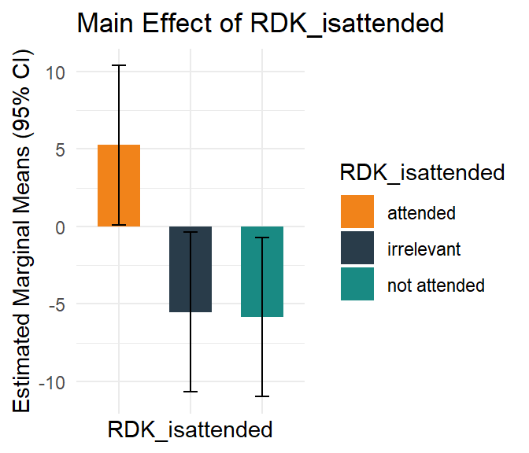

```r
#display main effects via emmeans
# Main effect of RDK_isattended
emm_ATT_lmm <- as.data.frame(emmeans(lmmmodel2, ~ RDK_isattended))

# Main effect of condition_label
emm_Pericondition_lmm <- as.data.frame(emmeans(lmmmodel2, ~ condition_label))

# RDK_isattended plot
ggplot(emm_ATT_lmm, aes(x = RDK_isattended, y = emmean, fill = RDK_isattended)) +
  geom_col(position = position_dodge(), width = 0.6) +
  geom_errorbar(aes(ymin = lower.CL, ymax = upper.CL), width = 0.2) +
  labs(title = "Main Effect of RDK_isattended",
       y = "Estimated Marginal Means (95% CI)", x = "RDK_isattended") +
  theme_minimal()+
  scale_fill_manual(values=c("#F1831A", "#293C4A", "#198A83"))+
  scale_color_manual(values=c("#F1831A", "#293C4A", "#198A83"))+
  theme(axis.text.x = element_blank())
```

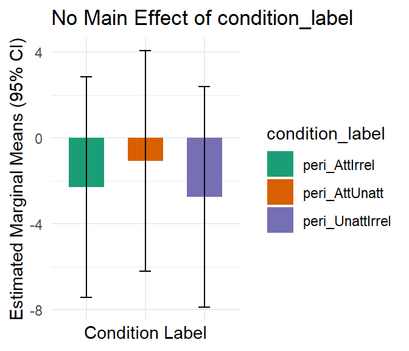

```r
# condition_label plot
ggplot(emm_Pericondition_lmm, aes(x = condition_label, y = emmean, fill = condition_label)) +
  geom_col(position = position_dodge(), width = 0.6) +
  geom_errorbar(aes(ymin = lower.CL, ymax = upper.CL), width = 0.2) +
  labs(title = "No Main Effect of condition_label",
       y = "Estimated Marginal Means (95% CI)", x = "Condition Label") +
  theme_minimal()+
  scale_fill_brewer(palette = "Dark2")+
  scale_color_brewer(palette = "Dark2")+
  theme(axis.text.x = element_blank())
```

```r
# firs test identity contrasts
#post hoc contrasts
post_hocs.RDK_isattended_id <- emmeans(lmmmodel2, c("RDK_isattended"), contr = "identity",adjust = "FDR") # adjust = FDr
post_hocs.condition_label_id <- emmeans(lmmmodel2, c("condition_label"), contr = "identity",adjust = "FDR") # adjust = FDR

# report data for post_hoc attention
post_hocs.RDK_isattended_id%>%
  .$contrasts %>%
  tidy()%>%
  dplyr::rename(t.ratio=statistic, p.value=adj.p.value)%>%
  mutate(
    p.value = cell_spec(ifelse(round(p.value,4)<.001,"< .001",round(p.value,4)),
                        color = ifelse(is.nan(p.value),"blue", ifelse(p.value < .05, "green", "red")),
                        bold = ifelse(is.nan(p.value),F, ifelse(p.value < .05, T,F)),
                        align = "left")
  ) %>% # mutate(CohensD = `t.ratio`/sqrt(df+1))%>%
  mutate(`CohensD` =
           summary(eff_size(post_hocs.RDK_isattended_id,
                            sigma = sqrt(mean(sigma(lmmmodel2$full_model)^2)), # RMS of sigma()
                            edf = df.residual(lmmmodel2$full_model), method = "identity"))$effect.size,
         `lowCI` =
           summary(eff_size(post_hocs.RDK_isattended_id,
                            sigma = sqrt(mean(sigma(lmmmodel2$full_model)^2)), # RMS of sigma()
                            edf = df.residual(lmmmodel2$full_model), method = "identity"))$lower.CL,
         `highCI` =
           summary(eff_size(post_hocs.RDK_isattended_id,
                            sigma = sqrt(mean(sigma(lmmmodel2$full_model)^2)), # RMS of sigma()
                            edf = df.residual(lmmmodel2$full_model), method = "identity"))$upper.CL
  )%>%
  kbl(escape = F, digits = c(3,3,3,3,3,3,3,3,3),
      caption = c("estimated marginal means | by ATTENTION | dv = peripheral SSVEP modulation | FDR corrected")) %>%
  kable_styling("striped", full_width = T, bootstrap_options = c("striped", "hover", "condensed", "responsive",font_size = 8))
```

estimated marginal means | by ATTENTION | dv = peripheral SSVEP modulation | FDR corrected

| term | contrast | null.value | estimate | std.error | df | t.ratio | p.value | CohensD | lowCI | highCI |
| --- | --- | --- | --- | --- | --- | --- | --- | --- | --- | --- |
| RDK_isattended | attended | 0 | 5.255 | 2.6 | 130.685 | 2.021 | 0.0453 | 0.229 | 0.004 | 0.455 |
| RDK_isattended | irrelevant | 0 | -5.529 | 2.6 | 130.685 | -2.127 | 0.0453 | -0.241 | -0.467 | -0.016 |
| RDK_isattended | not attended | 0 | -5.848 | 2.6 | 130.685 | -2.249 | 0.0453 | -0.255 | -0.481 | -0.030 |

```r
# report data for post_hoc condition_label
post_hocs.condition_label_id%>%
  .$contrasts %>%
  tidy()%>%
  dplyr::rename(t.ratio=statistic, p.value=adj.p.value)%>%
  mutate(
    p.value = cell_spec(ifelse(round(p.value,4)<.001,"< .001",round(p.value,4)),
                        color = ifelse(is.nan(p.value),"blue", ifelse(p.value < .05, "green", "red")),
                        bold = ifelse(is.nan(p.value),F, ifelse(p.value < .05, T,F)),
                        align = "left")
  ) %>% # mutate(CohensD = `t.ratio`/sqrt(df+1))%>%
  mutate(`CohensD` =
           summary(eff_size(post_hocs.condition_label_id,
                            sigma = sqrt(mean(sigma(lmmmodel2$full_model)^2)), # RMS of sigma()
                            edf = df.residual(lmmmodel2$full_model), method = "identity"))$effect.size,
         `lowCI` =
           summary(eff_size(post_hocs.condition_label_id,
                            sigma = sqrt(mean(sigma(lmmmodel2$full_model)^2)), # RMS of sigma()
                            edf = df.residual(lmmmodel2$full_model), method = "identity"))$lower.CL,
         `highCI` =
           summary(eff_size(post_hocs.condition_label_id,
                            sigma = sqrt(mean(sigma(lmmmodel2$full_model)^2)), # RMS of sigma()
                            edf = df.residual(lmmmodel2$full_model), method = "identity"))$upper.CL
  )%>%
  kbl(escape = F, digits = c(3,3,3,3,3,3,3,3,3),
      caption = c("estimated marginal means | by PERI_CON | dv = peripheral SSVEP modulation | FDR corrected")) %>%
  kable_styling("striped", full_width = T, bootstrap_options = c("striped", "hover", "condensed", "responsive",font_size = 8))
```

estimated marginal means | by PERI_CON | dv = peripheral SSVEP modulation | FDR corrected

| term | contrast | null.value | estimate | std.error | df | t.ratio | p.value | CohensD | lowCI | highCI |
| --- | --- | --- | --- | --- | --- | --- | --- | --- | --- | --- |
| condition_label | peri_AttIrrel | 0 | -2.289 | 2.6 | 130.685 | -0.880 | 0.5703 | -0.100 | -0.325 | 0.125 |
| condition_label | peri_AttUnatt | 0 | -1.077 | 2.6 | 130.685 | -0.414 | 0.6792 | -0.047 | -0.272 | 0.178 |
| condition_label | peri_UnattIrrel | 0 | -2.756 | 2.6 | 130.685 | -1.060 | 0.5703 | -0.120 | -0.345 | 0.104 |

```r
#post hoc contrasts
post_hocs.RDK_isattended <- emmeans(lmmmodel2, c("RDK_isattended"), contr = "pairwise",adjust = "FDR") # adjust = holm
post_hocs.condition_label <- emmeans(lmmmodel2, c("condition_label"), contr = "pairwise",adjust = "FDR") # adjust = holm

summary(post_hocs.RDK_isattended$contrasts) %>%
  mutate(
    p.value = cell_spec(ifelse(round(p.value,4)<.001,"< .001",round(p.value,4)),
                        color = ifelse(is.nan(p.value),"blue", ifelse(p.value < .05, "green", "red")),
                        bold = ifelse(is.nan(p.value),F, ifelse(p.value < .05, T,F)),
                        align = "left")
  ) %>%
  # mutate(CohensD = `t.ratio`/sqrt(df+1))%>%
  mutate(`CohensD` =
           summary(eff_size(post_hocs.RDK_isattended,
                            sigma = sqrt(mean(sigma(lmmmodel2$full_model)^2)), # RMS of sigma()
                            edf = df.residual(lmmmodel2$full_model), method = "pairwise"))$effect.size,
         `lowCI` =
           summary(eff_size(post_hocs.RDK_isattended,
                            sigma = sqrt(mean(sigma(lmmmodel2$full_model)^2)), # RMS of sigma()
                            edf = df.residual(lmmmodel2$full_model), method = "pairwise"))$lower.CL,
         `highCI` =
           summary(eff_size(post_hocs.RDK_isattended,
                            sigma = sqrt(mean(sigma(lmmmodel2$full_model)^2)), # RMS of sigma()
                            edf = df.residual(lmmmodel2$full_model), method = "pairwise"))$upper.CL
  )%>%
  kbl(escape = F, digits = c(3,3,3,3,3,3,3,3,3),
        caption = c("contrasts for estimated marginal means | by ATTENTION | dv = peripheral SSVEP modulation | corrected: FDR")) %>%
  kable_styling("striped", full_width = T, bootstrap_options = c("striped", "hover", "condensed", "responsive",font_size = 8))
```

contrasts for estimated marginal means | by ATTENTION | dv = peripheral SSVEP modulation | corrected: FDR

| contrast | estimate | SE | df | t.ratio | p.value | CohensD | lowCI | highCI |
| --- | --- | --- | --- | --- | --- | --- | --- | --- |
| attended - irrelevant | 10.784 | 3.415 | 232 | 3.158 | 0.0027 | 0.471 | 0.174 | 0.767 |
| attended - not attended | 11.103 | 3.415 | 232 | 3.251 | 0.0027 | 0.485 | 0.188 | 0.781 |
| irrelevant - not attended | 0.320 | 3.415 | 232 | 0.094 | 0.9255 | 0.014 | -0.280 | 0.308 |

```r
summary(post_hocs.condition_label$contrasts) %>%
  mutate(
    p.value = cell_spec(ifelse(round(p.value,4)<.001,"< .001",round(p.value,4)),
                        color = ifelse(is.nan(p.value),"blue", ifelse(p.value < .05, "green", "red")),
                        bold = ifelse(is.nan(p.value),F, ifelse(p.value < .05, T,F)),
                        align = "left")
  ) %>%
  # mutate(CohensD = `t.ratio`/sqrt(df+1))%>%
  mutate(`CohensD` =
           summary(eff_size(post_hocs.condition_label,
                            sigma = sqrt(mean(sigma(lmmmodel2$full_model)^2)), # RMS of sigma()
                            edf = df.residual(lmmmodel2$full_model), method = "pairwise"))$effect.size,
         `lowCI` =
           summary(eff_size(post_hocs.condition_label,
                            sigma = sqrt(mean(sigma(lmmmodel2$full_model)^2)), # RMS of sigma()
                            edf = df.residual(lmmmodel2$full_model), method = "pairwise"))$lower.CL,
         `highCI` =
           summary(eff_size(post_hocs.condition_label,
                            sigma = sqrt(mean(sigma(lmmmodel2$full_model)^2)), # RMS of sigma()
                            edf = df.residual(lmmmodel2$full_model), method = "pairwise"))$upper.CL
  )%>%
  kbl(escape = F, digits = c(3,3,3,3,3,3,3,3,3),
        caption = c("contrasts for estimated marginal means | by PERI_CON | dv = peripheral SSVEP modulation | corrected: FDR")) %>%
  kable_styling("striped", full_width = T, bootstrap_options = c("striped", "hover", "condensed", "responsive",font_size = 8))
```

contrasts for estimated marginal means | by PERI_CON | dv = peripheral SSVEP modulation | corrected: FDR

| contrast | estimate | SE | df | t.ratio | p.value | CohensD | lowCI | highCI |
| --- | --- | --- | --- | --- | --- | --- | --- | --- |
| peri_AttIrrel - peri_AttUnatt | -1.212 | 3.415 | 232 | -0.355 | 0.8915 | -0.053 | -0.347 | 0.241 |
| peri_AttIrrel - peri_UnattIrrel | 0.467 | 3.415 | 232 | 0.137 | 0.8915 | 0.020 | -0.273 | 0.314 |
| peri_AttUnatt - peri_UnattIrrel | 1.678 | 3.415 | 232 | 0.491 | 0.8915 | 0.073 | -0.221 | 0.367 |

```r
# pairs(emmeans(aovmodel2, ~ RDK_isattended))
# pairs(emmeans(aovmodel2, ~ condition_label))
```

## Some post-hoc add on analyses

### General post cue amplitudes across all conditions

**modulation** ~ **POSITION**

```r
dat2plot <- DataIn %>%
  filter(RDK_ispresented=="presented")%>%
  group_by(subjects, time, RDK_position2, RDK_colorlum)%>%
  summarise(amplitude_evoked=mean(amplitude_evoked), modulation_evoked=mean(modulation_evoked))%>%
  filter(time == '[0.5 1.5] ')

dat2plot %>%
  group_by(RDK_position2, RDK_colorlum)%>%
  nest()%>%
  mutate(stats = map(data, ~broom::tidy(
    t.test(modulation_evoked ~ 1, data = .)
  ))) %>%
  mutate(
    t_test_bf = map(data, ~{extractBF(ttestBF(x = .$modulation_evoked, data = .,iterations=num.iter,rscale = sqrt(2)/2))})
  )%>%
  mutate(meanval = map(data, ~ mean(.x$modulation_evoked))) %>%
  mutate(std = map(data, ~ sd(.x$modulation_evoked))) %>%
  dplyr::select(-data) %>%
  unnest(cols = c(stats, t_test_bf, meanval, std))%>%
  mutate(BF10 = bf, BF01 = 1/bf)%>%
  dplyr::select(RDK_colorlum, RDK_position2, meanval, std,  statistic, parameter, p.value, BF10, BF01)%>%
  mutate(p.value = p.adjust(p.value, method="holm")) %>% # none, holm
  # mutate(p.value = p.adjust(p.value, method="none")) %>% # none, holm
  ungroup()%>%
  mutate(CohensD = `statistic`/sqrt(parameter +1))%>%
  mutate(
    p.value = cell_spec(ifelse(round(p.value,4)<.001,"< .001",round(p.value,4)),
                        color = ifelse(is.nan(p.value),"blue", ifelse(p.value < .05, "green", "red")),
                        bold = ifelse(is.nan(p.value),F, ifelse(p.value < .05, T,F)),
                        align = "center")
  ) %>%
  kbl(escape = F, digits = c(3,3,3,3,3,3,3,3,3),
        caption = c("SSVEP | modulation | t-tests for modulation agains zero | Holm-corrected")) %>%
  kable_styling("striped", full_width = T, bootstrap_options = c("striped", "hover", "condensed", "responsive",font_size = 8))
```

| RDK_colorlum | RDK_position2 | meanval | std | statistic | parameter | p.value | BF10 | BF01 | CohensD |
| --- | --- | --- | --- | --- | --- | --- | --- | --- | --- |
| offset_to_bckgrd | center | 6.676 | 13.057 | 2.286 | 19 | 0.0339 | 1.890 | 0.529 | 0.511 |
| offset_to_bckgrd | peri | 6.510 | 8.669 | 3.358 | 19 | 0.0033 | 13.051 | 0.077 | 0.751 |
| isolum__to_bckgrd | center | 10.525 | 9.736 | 5.921 | 29 | < .001 | 9388.550 | 0.000 | 1.081 |
| isolum__to_bckgrd | peri | -3.748 | 10.791 | -1.902 | 29 | 0.0671 | 0.949 | 1.054 | -0.347 |

```r
dat2plot %>%
  dplyr::select(-amplitude_evoked)%>%
  pivot_wider(names_from = "RDK_position2", values_from = "modulation_evoked")%>%
  mutate(centerMINUSperi = `center` -`peri`)%>%
  group_by(time, RDK_colorlum)%>%
  nest()%>%
  mutate(stats = map(data, ~broom::tidy(
    t.test(centerMINUSperi ~ 1, data = .)
  ))) %>%
  mutate(
    t_test_bf = map(data, ~{extractBF(ttestBF(x = .$centerMINUSperi, data = .,iterations=num.iter,rscale = sqrt(2)/2))})
  )%>%
  mutate(meanval = map(data, ~ mean(.x$centerMINUSperi))) %>%
  mutate(std = map(data, ~ sd(.x$centerMINUSperi))) %>%
  ungroup()%>%
  dplyr::select(-data, -time) %>%
  unnest(cols = c(stats, t_test_bf, meanval, std))%>%
  mutate(BF10 = bf, BF01 = 1/bf)%>%
  dplyr::select(RDK_colorlum, meanval, std,  statistic, parameter, p.value, BF10, BF01)%>%
  # mutate(p.value = p.adjust(p.value, method="holm")) %>% # none, holm
  # mutate(p.value = p.adjust(p.value, method="none")) %>% # none, holm
  ungroup()%>%
  mutate(CohensD = `statistic`/sqrt(parameter +1))%>%
  mutate(
    p.value = cell_spec(ifelse(round(p.value,4)<.001,"< .001",round(p.value,4)),
                        color = ifelse(is.nan(p.value),"blue", ifelse(p.value < .05, "green", "red")),
                        bold = ifelse(is.nan(p.value),F, ifelse(p.value < .05, T,F)),
                        align = "center")
  ) %>%
  kbl(escape = F, digits = c(3,3,3,3,3,3,3,3,3), caption = c("SSVEP | modulation | center - peri ")) %>%
  kable_styling("striped", full_width = T, bootstrap_options = c("striped", "hover", "condensed", "responsive",font_size = 8))
```

SSVEP | modulation | center - peri

| RDK_colorlum | meanval | std | statistic | parameter | p.value | BF10 | BF01 | CohensD |
| --- | --- | --- | --- | --- | --- | --- | --- | --- |
| offset_to_bckgrd | 0.166 | 13.858 | 0.054 | 19 | 0.9578 | 0.233 | 4.299 | 0.012 |
| isolum__to_bckgrd | 14.274 | 15.783 | 4.953 | 29 | < .001 | 801.062 | 0.001 | 0.904 |

### analysis [displayed differently] | pre-cue differences

pre-cue differences?

**amplitude** ~ **condition**

ANOVA_RM: amplitude ~ CONDITION ( attended + irrelevant attended + not attended irrelevant + attended irrelevant + not attended not attended + attended not attended + irrelevant )

- post-hoc t-test contrasting differences between defined levels
- post-hoc t-test difference of post-cue modulation for attended vs unattended color

```r
dat2plot <- DataIn %>%
  filter(RDK_position2=="peri") %>%
  filter(RDK_ispresented=="presented")%>%
  group_by(subjects, time, RDK_isattended2, RDK_colorlum)%>%
  summarise(amplitude_evoked=mean(amplitude_evoked), modulation_evoked=mean(modulation_evoked))%>%
  filter(time == '[-1 0] ')

dat2plot2 <- DataIn %>%
  mutate(condition2 = case_when(
    (condition == 1 | condition == 2) ~ "peri_att_unatt",
    (condition == 3 | condition == 4) ~ "peri_att_irrel",
    (condition == 5 | condition == 6) ~ "peri_unatt_irrel",
  )) %>%
  filter(RDK_position2=="peri") %>%
  filter(RDK_ispresented=="presented")%>%
  group_by(subjects, time, RDK_isattended, RDK_colorlum, condition2)%>%
  summarise(amplitude_evoked=mean(amplitude_evoked), modulation_evoked=mean(modulation_evoked))%>%
  filter(time == '[-1 0] ')

dat2plot %>%
  group_by(RDK_colorlum, time)%>%
  nest()%>%
  mutate(stats= purrr::map(data, ~broom::tidy(
    anova(aov_ez(id="subjects", dv = "amplitude_evoked", data = ., within = "RDK_isattended2"))
  ))) %>%
  dplyr::select(-data) %>%
  unnest()%>%
  ungroup()%>%
  mutate(
    `p.value` = cell_spec(ifelse(round(`p.value`,4)<.001,"< .001",round(`p.value`,4)),
                        color = ifelse(is.nan(`p.value`),"blue", ifelse(`p.value` < .05, "green", "red")),
                        bold = ifelse(is.nan(`p.value`),F, ifelse(`p.value` < .05, T,F)),
                        align = "center")
  ) %>%
  dplyr::select(RDK_colorlum, term, `num.Df`, `den.Df`, MSE, `statistic`, ges, `p.value`) %>%
  kbl(escape = F, digits = c(3,3,3,3,3,3,3,3,3), caption = c("repeated measures ANOVA for peripheral SSVEP amplitudes")) %>%
  kable_styling("striped", full_width = T, bootstrap_options = c("striped", "hover", "condensed", "responsive",font_size = 8))
```

repeated measures ANOVA for peripheral SSVEP amplitudes

| RDK_colorlum | term | num.Df | den.Df | MSE | statistic | ges | p.value |
| --- | --- | --- | --- | --- | --- | --- | --- |
| offset_to_bckgrd | RDK_isattended2 | 1.753 | 33.314 | 0.290 | 1.093 | 0.018 | 0.3396 |
| isolum__to_bckgrd | RDK_isattended2 | 1.144 | 33.188 | 1.932 | 0.166 | 0.002 | 0.72 |

```r
dat2plot2 %>%
  group_by(RDK_colorlum, condition2, RDK_isattended)%>%
  nest()%>%
  mutate(stats = map(data, ~broom::tidy(
    t.test(amplitude_evoked ~ 1, data = .)
  ))) %>%
  mutate(
    t_test_bf = map(data, ~{extractBF(ttestBF(x = .$amplitude_evoked, data = .,iterations=num.iter,rscale = sqrt(2)/2))})
  )%>%
  mutate(meanval = map(data, ~ mean(.x$amplitude_evoked))) %>%
  mutate(std = map(data, ~ sd(.x$amplitude_evoked))) %>%
  dplyr::select(-data) %>%
  unnest(cols = c(stats, t_test_bf, meanval, std))%>%
  mutate(BF10 = bf, BF01 = 1/bf)%>%
  dplyr::select(RDK_colorlum,condition2, RDK_isattended, meanval, std,  statistic, parameter, p.value, BF10, BF01)%>%
  mutate(p.value = p.adjust(p.value, method="holm")) %>% # none, holm
  # mutate(p.value = p.adjust(p.value, method="none")) %>% # none, holm
  ungroup()%>%
  mutate(CohensD = `statistic`/sqrt(parameter +1))%>%
  mutate(
    p.value = cell_spec(ifelse(round(p.value,4)<.001,"< .001",round(p.value,4)),
                        color = ifelse(is.nan(p.value),"blue", ifelse(p.value < .05, "green", "red")),
                        bold = ifelse(is.nan(p.value),F, ifelse(p.value < .05, T,F)),
                        align = "center")
  ) %>%
  arrange(RDK_colorlum,condition2,RDK_isattended)%>%
  kbl(escape = F, digits = c(3,3,3,3,3,3,3,3,3),
        caption = c("peripheral SSVEP | modulation | t-tests for pre-cue amplitudes against zero | Holm-corrected")) %>%
  kable_styling("striped", full_width = T, bootstrap_options = c("striped", "hover", "condensed", "responsive",font_size = 8))
```

peripheral SSVEP | modulation | t-tests for pre-cue amplitudes against zero | Holm-corrected

| RDK_colorlum | condition2 | RDK_isattended | meanval | std | statistic | parameter | p.value | BF10 | BF01 | CohensD |
| --- | --- | --- | --- | --- | --- | --- | --- | --- | --- | --- |
| isolum__to_bckgrd | peri_att_irrel | attended | 1.780 | 0.965 | 10.103 | 29 | < .001 | 185052829.7 | 0 | 1.845 |
| isolum__to_bckgrd | peri_att_irrel | irrelevant | 1.717 | 0.895 | 10.509 | 29 | < .001 | 436903425.7 | 0 | 1.919 |
| isolum__to_bckgrd | peri_att_unatt | attended | 1.748 | 0.892 | 10.733 | 29 | < .001 | 696211857.4 | 0 | 1.960 |
| isolum__to_bckgrd | peri_att_unatt | not attended | 1.810 | 0.832 | 11.919 | 29 | < .001 | 7477479815.2 | 0 | 2.176 |
| isolum__to_bckgrd | peri_unatt_irrel | irrelevant | 1.726 | 0.933 | 10.137 | 29 | < .001 | 199088404.3 | 0 | 1.851 |
| isolum__to_bckgrd | peri_unatt_irrel | not attended | 1.843 | 0.985 | 10.247 | 29 | < .001 | 251646596.5 | 0 | 1.871 |
| offset_to_bckgrd | peri_att_irrel | attended | 1.171 | 0.512 | 10.236 | 19 | < .001 | 3231874.0 | 0 | 2.289 |
| offset_to_bckgrd | peri_att_irrel | irrelevant | 1.010 | 0.424 | 10.657 | 19 | < .001 | 5961364.2 | 0 | 2.383 |
| offset_to_bckgrd | peri_att_unatt | attended | 1.141 | 0.558 | 9.150 | 19 | < .001 | 614272.6 | 0 | 2.046 |
| offset_to_bckgrd | peri_att_unatt | not attended | 1.185 | 0.529 | 10.013 | 19 | < .001 | 2318984.8 | 0 | 2.239 |
| offset_to_bckgrd | peri_unatt_irrel | irrelevant | 1.039 | 0.489 | 9.497 | 19 | < .001 | 1057767.6 | 0 | 2.124 |
| offset_to_bckgrd | peri_unatt_irrel | not attended | 1.164 | 0.569 | 9.138 | 19 | < .001 | 602222.5 | 0 | 2.043 |

```r
dat2plot2 %>%
  dplyr::select(-modulation_evoked)%>%
  pivot_wider(names_from = "RDK_isattended", values_from = "amplitude_evoked")%>%
  mutate(`attended-notattended` = `attended` -`not attended`,
         `attended-irrelevant` = `attended` -`irrelevant`,
         `notattended-irrelevant` = `not attended` -`irrelevant`)%>%
  dplyr::select(-c(`attended`:`not attended`))%>%
  pivot_longer(cols=`attended-notattended`:`notattended-irrelevant`, names_to = "contrast", values_to = "amplitude")%>%
  drop_na(amplitude)%>%
  group_by(RDK_colorlum, condition2)%>%
  nest()%>%
  mutate(stats = map(data, ~broom::tidy(
    t.test(amplitude ~ 1, data = .)
  ))) %>%
  mutate(
    t_test_bf = map(data, ~{extractBF(ttestBF(x = .$amplitude, data = .,iterations=num.iter,rscale = sqrt(2)/2))})
  )%>%
  mutate(meanval = map(data, ~ mean(.x$amplitude))) %>%
  mutate(std = map(data, ~ sd(.x$amplitude))) %>%
  ungroup()%>%
  dplyr::select(-data) %>%
  unnest(cols = c(stats, t_test_bf, meanval, std))%>%
  mutate(BF10 = bf, BF01 = 1/bf)%>%
  dplyr::select(RDK_colorlum, condition2, meanval, std,  statistic, parameter, p.value, BF10, BF01)%>%
  # mutate(p.value = p.adjust(p.value, method="holm")) %>% # none, holm
  # mutate(p.value = p.adjust(p.value, method="none")) %>% # none, holm
  ungroup()%>%
  mutate(CohensD = `statistic`/sqrt(parameter +1))%>%
  mutate(
    p.value = cell_spec(ifelse(round(p.value,4)<.001,"< .001",round(p.value,4)),
                        color = ifelse(is.nan(p.value),"blue", ifelse(p.value < .05, "green", "red")),
                        bold = ifelse(is.nan(p.value),F, ifelse(p.value < .05, T,F)),
                        align = "center")
  ) %>%
  kbl(escape = F, digits = c(3,3,3,3,3,3,3,3,3), caption = c("peripheral SSVEP | pre-cue amplitudes | contrasts")) %>%
  kable_styling("striped", full_width = T, bootstrap_options = c("striped", "hover", "condensed", "responsive",font_size = 8))
```

peripheral SSVEP | pre-cue amplitudes | contrasts

| RDK_colorlum | condition2 | meanval | std | statistic | parameter | p.value | BF10 | BF01 | CohensD |
| --- | --- | --- | --- | --- | --- | --- | --- | --- | --- |
| offset_to_bckgrd | peri_att_irrel | 0.162 | 0.562 | 1.286 | 19 | 0.214 | 0.476 | 2.099 | 0.287 |
| offset_to_bckgrd | peri_att_unatt | -0.044 | 0.172 | -1.131 | 19 | 0.2721 | 0.407 | 2.456 | -0.253 |
| offset_to_bckgrd | peri_unatt_irrel | 0.124 | 0.616 | 0.902 | 19 | 0.3782 | 0.333 | 3.000 | 0.202 |
| isolum__to_bckgrd | peri_att_irrel | 0.063 | 1.318 | 0.262 | 29 | 0.7954 | 0.201 | 4.984 | 0.048 |
| isolum__to_bckgrd | peri_att_unatt | -0.063 | 0.233 | -1.471 | 29 | 0.1521 | 0.513 | 1.951 | -0.269 |
| isolum__to_bckgrd | peri_unatt_irrel | 0.117 | 1.345 | 0.476 | 29 | 0.6376 | 0.216 | 4.633 | 0.087 |